# Practicum 1 Analysis

Peter Claussen

Ben Derenge

Stephanie Liebl

9/16/2021

# Analysis

## Data Processing

Our initial step in processing the ‘Practicum 1 Data’ dataset was to remove any rows where the `Snumber` column was “NA”. We identified the `Snumber` column as a unique identifier, and thus were only concerned with nonempty rows. Initially, the dataset has 392 rows. After removing removing the ‘NA’ identifiers, we are left with 352 rows.

```r
metrics.dat <- read.csv('Practicum 1 Data.csv',header=TRUE)
metrics.dat <- metrics.dat[!is.na(metrics.dat$Snumber),]
```

Next, we verified that the column `Total_Met_Min` had correct computations. We created a separate column `CalcTMM` to check against the values in `Total_Met_Min`. In our observations of the `shift` variable, we discovered that there existed an ‘other’ category and missing values. We decided to refrain from combining these categories and created a ‘missing’ category for values of `shift` that were blank.

```r
metrics.dat$CalcTMM <- with(metrics.dat, 8*Vig.ex.Time + 4*Mod.ex.time + 3.3*Walk.ex.Time)

metrics.dat$shift[metrics.dat$shift==''] <- 'missing'
shift.levels <- c(paste(c(7:11),'am',sep=''),paste(c(12,1:2),'pm',sep=''),'other','missing')
metrics.dat$shift <- factor(metrics.dat$shift,shift.levels)
summary(metrics.dat$shift)
```

```
##     7am     8am     9am    10am    11am    12pm     1pm     2pm   other missing
##      31     115      56      50      44      14       8      15      15       4
```

```r
metrics.dat$MissingLbs <- is.na(metrics.dat$pounds_gained)
table(metrics.dat$MissingLbs,metrics.dat$weightgain)
```

```
##
##              No Yes
##   FALSE   0   1 231
##   TRUE    4 110   6
```

We consider two subsets for analysis. First we create a data table that has appropriate values for `weightgain`. This will be the larger of the two data sets. Our original dataset contained a binary ‘yes/no’ column titled `weightgain`. This column was missing data for four rows, and thus, we subset the data to obtain a data table with values for `weightgain` in all rows. This data table left us with 348 rows. It should be noted that the original dataset contains a numeric `pounds_gained` column as well. This column had many missing values, but we were able to impute a ‘0’ if we knew that row had a ‘No’ for `weightgain`. Lastly, we observed a single missing value for the column `CalcTMM`, and so we once more subset the data to obtain a table with values of `CalcTMM` for all rows.

```r
gained.dat <- metrics.dat[metrics.dat$weightgain %in% c('Yes','No'),]
gained.dat$WG <- FALSE
gained.dat$WG[gained.dat$weightgain=='Yes'] <- TRUE
gained.dat$pounds_gained[!gained.dat$WG] <- 0
dim(gained.dat)
```

```
## [1] 348  86
```

```r
gained.dat$MissingLbs <- is.na(gained.dat$pounds_gained)
table(gained.dat$MissingLbs,gained.dat$weightgain)
```

```
##
##          No Yes
##   FALSE 111 231
##   TRUE    0   6
```

```r
gained.dat <- gained.dat[!is.na(gained.dat$CalcTMM),]
dim(gained.dat)
```

```
## [1] 347  86
```

```r
#gained.dat <- gained.dat[!gained.dat$MissingLbs,]
dim(gained.dat)
```

```
## [1] 347  86
```

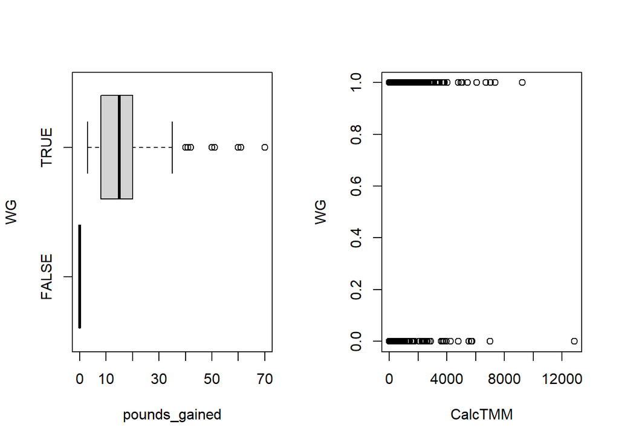

```r
par(mfrow=c(1,2))
boxplot(pounds_gained ~ WG,data=gained.dat,horizontal = TRUE)
plot(WG~CalcTMM,data=gained.dat)
```

# Analysis of Binary Response (WG)

## **(SA1)** Does *total metabolic minutes* have an effect on *weight gain*?

### Simple logistic regression

The client provided us two specific aims to address in our analysis. We will begin with the first specific aim, which we will refer to as SA1. SA1 says, “Does total metabolic minutes have an effect on weight gain?”. To address this question, we began by creating a simple linear regression model of our binary weight gain versus calculated total metabolic minutes. The summary output of this model suggests that `CalcTMM` has very little effect on weight gain, as the p-value for `CalcTMM` is 0.21, quite large.

```r
SA1.model1 <- glm(WG ~ CalcTMM, data=gained.dat,family = binomial)
summary(SA1.model1)
```

```
##
## Call:
## glm(formula = WG ~ CalcTMM, family = binomial, data = gained.dat)
##
## Deviance Residuals:
##     Min       1Q   Median       3Q      Max
## -1.5702  -1.4777   0.8403   0.8697   1.1523
##
## Coefficients:
##               Estimate Std. Error z value Pr(>|z|)
## (Intercept)  8.882e-01  1.517e-01   5.855 4.78e-09 ***
## CalcTMM     -8.959e-05  7.141e-05  -1.255     0.21
## ---
## Signif. codes:  0 '***' 0.001 '**' 0.01 '*' 0.05 '.' 0.1 ' ' 1
##
## (Dispersion parameter for binomial family taken to be 1)
##
##     Null deviance: 433.47  on 346  degrees of freedom
## Residual deviance: 431.91  on 345  degrees of freedom
## AIC: 435.91
##
## Number of Fisher Scoring iterations: 4
```

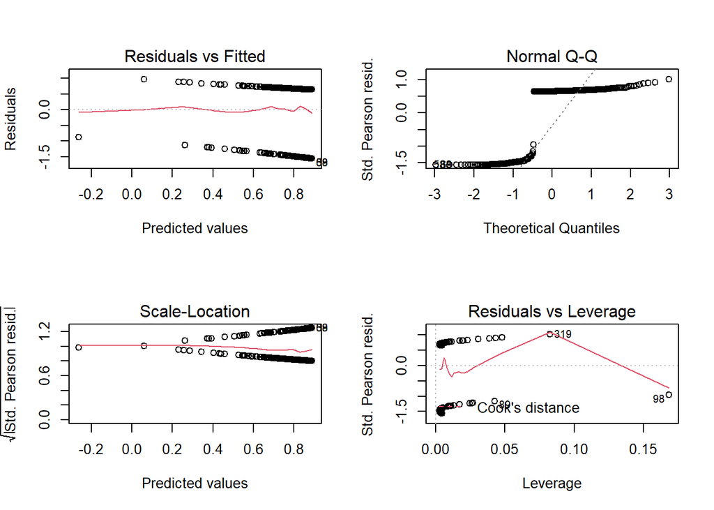

```r
par(mfrow=c(2,2))
plot(SA1.model1)
```

- **(SA2)** Does *shift* have an effect on *weight gain*? The second specific aim given to us by the client says, “Does shift have an effect on weight gain?”. To address this question, we began by creating a simple linear regression model of our binary weight gain versus shift. From the summary output of this model, we see that no value of shift seems to have much significance in the model. The p-value for each of these values is greater than 0.1, suggesting each has little effect on weight gain.

```r
SA2.model1 <- glm(WG ~ shift, data=gained.dat,family = binomial)
summary(SA2.model1)
```

```
##
## Call:
## glm(formula = WG ~ shift, family = binomial, data = gained.dat)
##
## Deviance Residuals:
##     Min       1Q   Median       3Q      Max
## -1.7941  -1.4006   0.7585   0.9400   0.9695
##
## Coefficients:
##              Estimate Std. Error z value Pr(>|z|)
## (Intercept)   0.54654    0.37887   1.443    0.149
## shift8am      0.25482    0.43004   0.593    0.553
## shift9am     -0.03572    0.46875  -0.076    0.939
## shift10am     0.57947    0.50389   1.150    0.250
## shift11am    -0.02330    0.49303  -0.047    0.962
## shift12pm     0.04124    0.67428   0.061    0.951
## shift1pm     -0.03572    0.82272  -0.043    0.965
## shift2pm      0.83975    0.74847   1.122    0.262
## shiftother    0.83975    0.74847   1.122    0.262
## shiftmissing  0.55207    1.21527   0.454    0.650
##
## (Dispersion parameter for binomial family taken to be 1)
##
##     Null deviance: 433.47  on 346  degrees of freedom
## Residual deviance: 428.07  on 337  degrees of freedom
## AIC: 448.07
##
## Number of Fisher Scoring iterations: 4
```

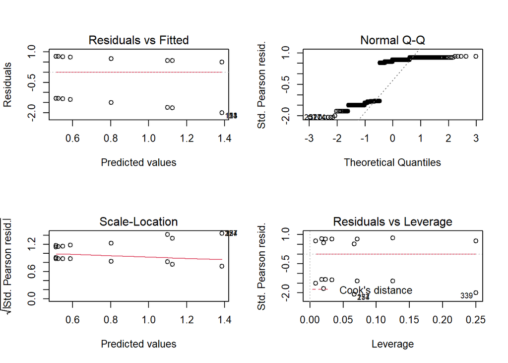

```r
par(mfrow=c(2,2))
plot(SA2.model1)
```

# Model 2 Interactions

After observing the models representing weight gain versus total met minutes and shift, respectively, we sought to examine whether `shift`*`CalcTMM` had an effect on weight gain.

```r
SA12.model2 <- glm(WG ~ shift*CalcTMM, data=gained.dat,family = binomial)
summary(SA12.model2)
```

```
##
## Call:
## glm(formula = WG ~ shift * CalcTMM, family = binomial, data = gained.dat)
##
## Deviance Residuals:
##     Min       1Q   Median       3Q      Max
## -1.9466  -1.3601   0.7528   0.9131   1.6031
##
## Coefficients:
##                        Estimate Std. Error z value Pr(>|z|)
## (Intercept)           1.060e+00  5.867e-01   1.806   0.0709 .
## shift8am              8.686e-02  6.470e-01   0.134   0.8932
## shift9am             -6.779e-01  6.792e-01  -0.998   0.3182
## shift10am             6.941e-01  8.161e-01   0.851   0.3950
## shift11am            -6.229e-01  7.194e-01  -0.866   0.3866
## shift12pm            -2.265e-01  1.000e+00  -0.226   0.8209
## shift1pm              7.634e-02  1.377e+00   0.055   0.9558
## shift2pm              2.430e-01  1.101e+00   0.221   0.8253
## shiftother           -2.021e+00  1.530e+00  -1.321   0.1867
## shiftmissing         -5.425e-01  1.894e+00  -0.286   0.7746
## CalcTMM              -3.565e-04  2.972e-04  -1.200   0.2303
## shift8am:CalcTMM      1.019e-04  3.249e-04   0.314   0.7538
## shift9am:CalcTMM      4.652e-04  3.455e-04   1.346   0.1782
## shift10am:CalcTMM    -6.172e-05  4.110e-04  -0.150   0.8806
## shift11am:CalcTMM     4.393e-04  3.977e-04   1.105   0.2693
## shift12pm:CalcTMM     1.608e-04  5.436e-04   0.296   0.7674
## shift1pm:CalcTMM     -1.489e-04  8.233e-04  -0.181   0.8565
## shift2pm:CalcTMM      4.062e-04  5.046e-04   0.805   0.4209
## shiftother:CalcTMM    4.209e-03  2.796e-03   1.505   0.1323
## shiftmissing:CalcTMM  7.393e-04  1.046e-03   0.707   0.4797
## ---
## Signif. codes:  0 '***' 0.001 '**' 0.01 '*' 0.05 '.' 0.1 ' ' 1
##
## (Dispersion parameter for binomial family taken to be 1)
##
##     Null deviance: 433.47  on 346  degrees of freedom
## Residual deviance: 412.95  on 327  degrees of freedom
## AIC: 452.95
##
## Number of Fisher Scoring iterations: 8
```

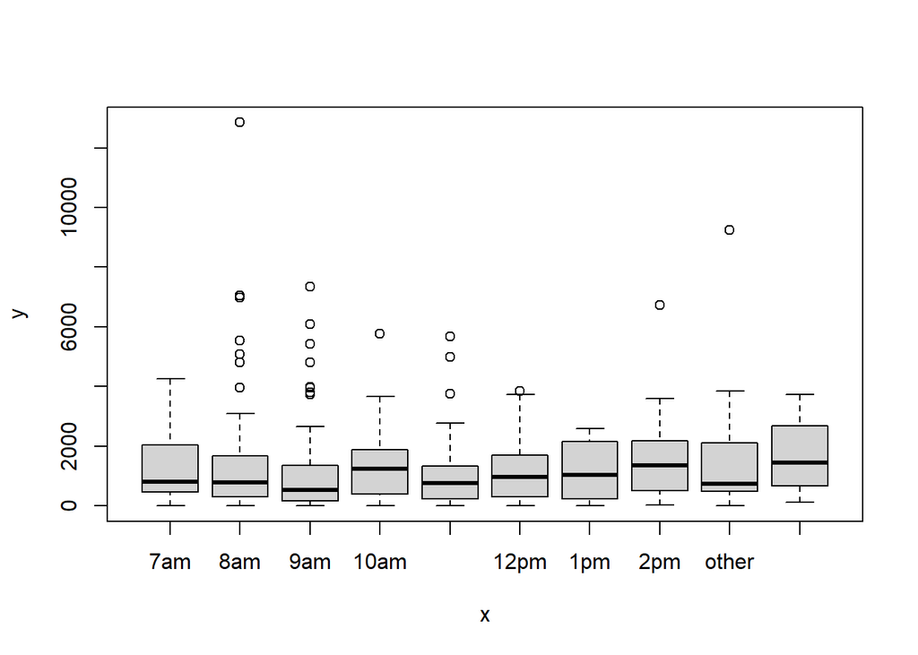

```r
plot(metrics.dat$shift, metrics.dat$CalcTMM)
plot(metrics.dat$shift,metrics.dat$CalcTMM)
```

# Model 3 SA1 and 2 plus anthropometric variables

The original dataset included anthropometric variables such as `gender`, `Age`, `height`, and `BMI`. We wanted to inspect whether such variables effect weight gain, and so we created a generalized linear model including them. We began by including just variables for gender and age, and then height. It can be seen that the p-values for these variables in both models are large, suggesting little effect on weight gain.

```r
subset3a.dat <- gained.dat[which(complete.cases(gained.dat[, c("gender", "Age", "shift", "CalcTMM")])),]
SA12.model3a <- glm(WG ~ gender + Age + shift + CalcTMM, data=subset3a.dat,family = binomial)
summary(SA12.model3a)
```

```
##
## Call:
## glm(formula = WG ~ gender + Age + shift + CalcTMM, family = binomial,
##     data = subset3a.dat)
##
## Deviance Residuals:
##     Min       1Q   Median       3Q      Max
## -1.9936  -1.3159   0.7661   0.8673   1.4101
##
## Coefficients:
##                Estimate Std. Error z value Pr(>|z|)
## (Intercept)   1.897e-01  1.623e+00   0.117    0.907
## genderFemale  1.240e+00  1.472e+00   0.842    0.400
## genderMale    7.071e-01  1.486e+00   0.476    0.634
## Age          -6.189e-03  1.263e-02  -0.490    0.624
## shift8am     -1.491e-01  4.821e-01  -0.309    0.757
## shift9am     -3.842e-01  5.240e-01  -0.733    0.464
## shift10am     1.715e-01  5.524e-01   0.310    0.756
## shift11am    -1.932e-01  5.542e-01  -0.349    0.727
## shift12pm    -4.140e-01  7.192e-01  -0.576    0.565
## shift1pm     -4.538e-01  8.572e-01  -0.529    0.597
## shift2pm      1.331e+00  1.151e+00   1.157    0.247
## shiftother    5.339e-01  8.128e-01   0.657    0.511
## shiftmissing  1.374e+01  6.107e+02   0.022    0.982
## CalcTMM      -1.102e-04  7.636e-05  -1.444    0.149
##
## (Dispersion parameter for binomial family taken to be 1)
##
##     Null deviance: 393.55  on 318  degrees of freedom
## Residual deviance: 379.52  on 305  degrees of freedom
## AIC: 407.52
##
## Number of Fisher Scoring iterations: 13
```

```r
subset3b.dat <- gained.dat[which(complete.cases(gained.dat[, c("gender", "Age", "height","shift", "CalcTMM")])),]
SA12.model3b <- glm(WG ~ gender + Age + height +shift + CalcTMM, data=subset3b.dat,family = binomial)
summary(SA12.model3b)
```

```
##
## Call:
## glm(formula = WG ~ gender + Age + height + shift + CalcTMM, family = binomial,
##     data = subset3b.dat)
##
## Deviance Residuals:
##     Min       1Q   Median       3Q      Max
## -1.9392  -1.2928   0.7580   0.8566   1.3899
##
## Coefficients:
##                Estimate Std. Error z value Pr(>|z|)
## (Intercept)  -1.657e-01  3.381e+00  -0.049    0.961
## genderFemale  1.268e+00  1.489e+00   0.852    0.394
## genderMale    6.805e-01  1.486e+00   0.458    0.647
## Age          -2.496e-03  1.294e-02  -0.193    0.847
## height        3.124e-03  4.170e-02   0.075    0.940
## shift8am     -1.112e-01  4.834e-01  -0.230    0.818
## shift9am     -3.525e-01  5.278e-01  -0.668    0.504
## shift10am     2.318e-01  5.611e-01   0.413    0.680
## shift11am    -1.797e-01  5.549e-01  -0.324    0.746
## shift12pm    -4.107e-01  7.199e-01  -0.571    0.568
## shift1pm     -4.402e-01  8.578e-01  -0.513    0.608
## shift2pm      1.339e+00  1.153e+00   1.161    0.246
## shiftother    4.589e-01  8.196e-01   0.560    0.576
## shiftmissing  1.375e+01  6.104e+02   0.023    0.982
## CalcTMM      -1.052e-04  7.680e-05  -1.370    0.171
##
## (Dispersion parameter for binomial family taken to be 1)
##
##     Null deviance: 384.25  on 312  degrees of freedom
## Residual deviance: 370.32  on 298  degrees of freedom
## AIC: 400.32
##
## Number of Fisher Scoring iterations: 13
```

# Model 4 Partition CalcTMM into components

In the background information given to us by our client, it stated that the `Total_Met_Min` column was calculated by a combination of `Vig.ex.Time`, `Mod.ex.Time`, and `Walk.ex.Time`. Although as previously discovered, total met minutes as a whole does not have a large effect on weight gain, we wanted to determine whether its individual components have an effect.

```r
subset4a.dat <- gained.dat[which(complete.cases(gained.dat[, c("gender", "Age", "shift", "Vig.ex.Time", "Mod.ex.time", "Walk.ex.Time")])),]
SA12.model4a <- glm(WG ~ gender + Age + shift + Vig.ex.Time  + Mod.ex.time + Walk.ex.Time, data=subset4a.dat, family = binomial)
summary(SA12.model4a)
```

```
##
## Call:
## glm(formula = WG ~ gender + Age + shift + Vig.ex.Time + Mod.ex.time +
##     Walk.ex.Time, family = binomial, data = subset4a.dat)
##
## Deviance Residuals:
##     Min       1Q   Median       3Q      Max
## -1.9919  -1.3054   0.7611   0.8657   1.4278
##
## Coefficients:
##                Estimate Std. Error z value Pr(>|z|)
## (Intercept)   3.761e-01  1.662e+00   0.226    0.821
## genderFemale  1.046e+00  1.517e+00   0.690    0.490
## genderMale    5.222e-01  1.527e+00   0.342    0.732
## Age          -6.569e-03  1.269e-02  -0.518    0.605
## shift8am     -1.245e-01  4.846e-01  -0.257    0.797
## shift9am     -3.901e-01  5.260e-01  -0.742    0.458
## shift10am     2.003e-01  5.557e-01   0.360    0.719
## shift11am    -1.591e-01  5.583e-01  -0.285    0.776
## shift12pm    -4.125e-01  7.198e-01  -0.573    0.567
## shift1pm     -4.500e-01  8.575e-01  -0.525    0.600
## shift2pm      1.336e+00  1.160e+00   1.152    0.249
## shiftother    5.447e-01  8.137e-01   0.669    0.503
## shiftmissing  1.376e+01  6.103e+02   0.023    0.982
## Vig.ex.Time  -1.434e-03  1.231e-03  -1.165    0.244
## Mod.ex.time  -4.887e-05  1.167e-03  -0.042    0.967
## Walk.ex.Time -2.474e-04  5.875e-04  -0.421    0.674
##
## (Dispersion parameter for binomial family taken to be 1)
##
##     Null deviance: 393.55  on 318  degrees of freedom
## Residual deviance: 379.25  on 303  degrees of freedom
## AIC: 411.25
##
## Number of Fisher Scoring iterations: 13
```

```r
subset4b.dat <- gained.dat[which(complete.cases(gained.dat[, c("gender", "Age", "height", "shift", "Vig.ex.Time", "Mod.ex.time", "Walk.ex.Time")])),]
SA12.model4b <- glm(WG ~ gender + Age + height + shift + Vig.ex.Time  + Mod.ex.time + Walk.ex.Time, data=subset4b.dat, family = binomial)
summary(SA12.model4b)
```

```
##
## Call:
## glm(formula = WG ~ gender + Age + height + shift + Vig.ex.Time +
##     Mod.ex.time + Walk.ex.Time, family = binomial, data = subset4b.dat)
##
## Deviance Residuals:
##     Min       1Q   Median       3Q      Max
## -1.9366  -1.2871   0.7556   0.8564   1.3901
##
## Coefficients:
##                Estimate Std. Error z value Pr(>|z|)
## (Intercept)  -3.843e-03  3.414e+00  -0.001    0.999
## genderFemale  1.092e+00  1.540e+00   0.709    0.478
## genderMale    5.064e-01  1.531e+00   0.331    0.741
## Age          -2.712e-03  1.301e-02  -0.208    0.835
## height        3.138e-03  4.175e-02   0.075    0.940
## shift8am     -8.385e-02  4.860e-01  -0.173    0.863
## shift9am     -3.485e-01  5.298e-01  -0.658    0.511
## shift10am     2.608e-01  5.638e-01   0.463    0.644
## shift11am    -1.447e-01  5.592e-01  -0.259    0.796
## shift12pm    -4.137e-01  7.202e-01  -0.574    0.566
## shift1pm     -4.334e-01  8.579e-01  -0.505    0.613
## shift2pm      1.321e+00  1.163e+00   1.136    0.256
## shiftother    4.707e-01  8.202e-01   0.574    0.566
## shiftmissing  1.377e+01  6.105e+02   0.023    0.982
## Vig.ex.Time  -1.348e-03  1.259e-03  -1.071    0.284
## Mod.ex.time   1.043e-04  1.198e-03   0.087    0.931
## Walk.ex.Time -3.354e-04  5.892e-04  -0.569    0.569
##
## (Dispersion parameter for binomial family taken to be 1)
##
##     Null deviance: 384.25  on 312  degrees of freedom
## Residual deviance: 370.06  on 296  degrees of freedom
## AIC: 404.06
##
## Number of Fisher Scoring iterations: 13
```

# Model 5 - Model 4 plus BMI and initial body weight

For these models, we may include BMI, or just the anthropometric variables used to calculate BMI. Using the columns for body weight, height, and pounds gained, we were able to obtain `initial_BMI` and `initial_bweight` columns.

```r
gained.dat['initial_bweight'] <- gained.dat$bweight - gained.dat$pounds_gained
gained.dat['initial_BMI'] <- (gained.dat$initial_bweight / (gained.dat$height)^2)*703
```

In the following models, we used the anthropometric variables, the individual total met minute components in addition to the initial BMI and initial body weight variables, respectively. We know that BMI is calculated using height and weight, so we avoided using all three (`initial_BMI`, `height`, `initial_bweight`) in a model to avoid multicollinearity (?). We see that in the first model, `initial_BMI` has a small p-value and in the second model, `initial_bweight` has a small p-value. This suggests that the variables effect weight gain in their respective model.

```r
subset5a.dat <- gained.dat[which(complete.cases(gained.dat[, c("gender", "Age", "shift", "Vig.ex.Time", "Mod.ex.time", "Walk.ex.Time", "initial_BMI")])),]
SA12.model5a <- glm(WG ~ gender + Age + shift + Vig.ex.Time  + Mod.ex.time + Walk.ex.Time + initial_BMI, data=subset5a.dat, family = binomial)
summary(SA12.model5a)
```

```
##
## Call:
## glm(formula = WG ~ gender + Age + shift + Vig.ex.Time + Mod.ex.time +
##     Walk.ex.Time + initial_BMI, family = binomial, data = subset5a.dat)
##
## Deviance Residuals:
##     Min       1Q   Median       3Q      Max
## -2.0146  -1.1930   0.7081   0.8825   1.3010
##
## Coefficients:
##                Estimate Std. Error z value Pr(>|z|)
## (Intercept)   5.545e-01  1.816e+00   0.305   0.7602
## genderFemale  1.475e+00  1.555e+00   0.949   0.3428
## genderMale    9.743e-01  1.570e+00   0.620   0.5349
## Age           1.258e-02  1.536e-02   0.819   0.4128
## shift8am     -2.794e-01  5.425e-01  -0.515   0.6065
## shift9am      1.927e-01  6.331e-01   0.304   0.7609
## shift10am     5.366e-01  6.421e-01   0.836   0.4034
## shift11am    -2.815e-01  6.246e-01  -0.451   0.6523
## shift12pm     3.545e-01  8.427e-01   0.421   0.6740
## shift1pm      6.780e-02  1.023e+00   0.066   0.9471
## shift2pm      1.590e+01  9.545e+02   0.017   0.9867
## shiftother    4.309e-01  8.647e-01   0.498   0.6182
## shiftmissing  1.613e+01  1.675e+03   0.010   0.9923
## Vig.ex.Time  -4.905e-04  1.427e-03  -0.344   0.7310
## Mod.ex.time  -5.897e-04  1.473e-03  -0.400   0.6889
## Walk.ex.Time -3.366e-04  6.597e-04  -0.510   0.6098
## initial_BMI  -5.306e-02  2.664e-02  -1.992   0.0464 *
## ---
## Signif. codes:  0 '***' 0.001 '**' 0.01 '*' 0.05 '.' 0.1 ' ' 1
##
## (Dispersion parameter for binomial family taken to be 1)
##
##     Null deviance: 301.19  on 241  degrees of freedom
## Residual deviance: 280.85  on 225  degrees of freedom
## AIC: 314.85
##
## Number of Fisher Scoring iterations: 15
```

```r
subset5b.dat <- gained.dat[which(complete.cases(gained.dat[, c("gender", "Age", "height", "shift", "Vig.ex.Time", "Mod.ex.time", "Walk.ex.Time", "initial_bweight")])),]
SA12.model5b <- glm(WG ~ gender + Age + height + shift + Vig.ex.Time  + Mod.ex.time + Walk.ex.Time +initial_bweight, data=subset5b.dat, family = binomial)
summary(SA12.model5b)
```

```
##
## Call:
## glm(formula = WG ~ gender + Age + height + shift + Vig.ex.Time +
##     Mod.ex.time + Walk.ex.Time + initial_bweight, family = binomial,
##     data = subset5b.dat)
##
## Deviance Residuals:
##     Min       1Q   Median       3Q      Max
## -1.9710  -1.2121   0.7130   0.8866   1.3026
##
## Coefficients:
##                   Estimate Std. Error z value Pr(>|z|)
## (Intercept)     -2.567e+00  3.891e+00  -0.660   0.5095
## genderFemale     1.520e+00  1.581e+00   0.962   0.3362
## genderMale       9.834e-01  1.572e+00   0.626   0.5316
## Age              1.207e-02  1.539e-02   0.785   0.4326
## height           4.495e-02  5.134e-02   0.875   0.3813
## shift8am        -2.806e-01  5.430e-01  -0.517   0.6053
## shift9am         1.854e-01  6.329e-01   0.293   0.7696
## shift10am        5.229e-01  6.434e-01   0.813   0.4164
## shift11am       -2.799e-01  6.261e-01  -0.447   0.6549
## shift12pm        3.139e-01  8.410e-01   0.373   0.7090
## shift1pm         5.388e-02  1.018e+00   0.053   0.9578
## shift2pm         1.594e+01  9.521e+02   0.017   0.9866
## shiftother       4.353e-01  8.649e-01   0.503   0.6147
## shiftmissing     1.611e+01  1.670e+03   0.010   0.9923
## Vig.ex.Time     -4.464e-04  1.425e-03  -0.313   0.7541
## Mod.ex.time     -6.272e-04  1.471e-03  -0.426   0.6699
## Walk.ex.Time    -3.272e-04  6.621e-04  -0.494   0.6211
## initial_bweight -7.707e-03  4.215e-03  -1.828   0.0675 .
## ---
## Signif. codes:  0 '***' 0.001 '**' 0.01 '*' 0.05 '.' 0.1 ' ' 1
##
## (Dispersion parameter for binomial family taken to be 1)
##
##     Null deviance: 301.19  on 241  degrees of freedom
## Residual deviance: 281.36  on 224  degrees of freedom
## AIC: 317.36
##
## Number of Fisher Scoring iterations: 15
```

## Model 6

Lastly, we wanted to observe the binomial models created from `initial_BMI`x`shift`x`CalcTMM` as well as `initial_bweight`x`shift`x`CalcTMM`. We then ran the stepAIC() function through both models, and obtained a lower AIC value for the model using `initial_BMI`x`shift`x`CalcTMM`. This suggests this model is simpler than the other. In this model, the following predictors had p-values <0.1: shift10am:CalcTMM, initial_BMI:shift10am:CalcTMM. This suggests that these products are significant in predicting whether an employee has gained weight.

```
## Start:  AIC=326.73
## WG ~ initial_BMI * shift * CalcTMM
##
##                             Df Deviance    AIC
## <none>                           250.73 326.73
## - initial_BMI:shift:CalcTMM  8   268.77 328.77
```

```
##
## Call:
## glm(formula = WG ~ initial_BMI * shift * CalcTMM, family = binomial,
##     data = subset6a.dat)
##
## Deviance Residuals:
##     Min       1Q   Median       3Q      Max
## -2.2295  -0.9002   0.4075   0.8848   1.7377
##
## Coefficients: (2 not defined because of singularities)
##                                    Estimate Std. Error z value Pr(>|z|)
## (Intercept)                      -2.628e-01  6.010e+00  -0.044   0.9651
## initial_BMI                       2.560e-02  2.107e-01   0.122   0.9033
## shift8am                          2.106e+00  6.172e+00   0.341   0.7329
## shift9am                          1.581e+00  6.427e+00   0.246   0.8057
## shift10am                         3.699e+00  7.138e+00   0.518   0.6044
## shift11am                         2.334e+00  6.698e+00   0.348   0.7275
## shift12pm                        -3.378e+01  3.150e+01  -1.072   0.2836
## shift1pm                         -1.231e+02  9.497e+03  -0.013   0.9897
## shift2pm                          9.971e+00  1.507e+01   0.662   0.5082
## shiftother                        8.126e+00  1.250e+01   0.650   0.5157
## shiftmissing                      4.995e+01  1.166e+05   0.000   0.9997
## CalcTMM                           7.085e-03  6.059e-03   1.169   0.2423
## initial_BMI:shift8am             -6.524e-02  2.174e-01  -0.300   0.7641
## initial_BMI:shift9am             -4.026e-02  2.243e-01  -0.180   0.8575
## initial_BMI:shift10am            -4.925e-02  2.552e-01  -0.193   0.8470
## initial_BMI:shift11am            -1.263e-01  2.412e-01  -0.524   0.6005
## initial_BMI:shift12pm             1.555e+00  1.404e+00   1.108   0.2679
## initial_BMI:shift1pm              5.311e+00  3.915e+02   0.014   0.9892
## initial_BMI:shift2pm             -4.352e-01  6.045e-01  -0.720   0.4716
## initial_BMI:shiftother           -3.578e-01  4.766e-01  -0.751   0.4528
## initial_BMI:shiftmissing         -1.042e+00  3.640e+03   0.000   0.9998
## initial_BMI:CalcTMM              -2.448e-04  2.083e-04  -1.175   0.2401
## shift8am:CalcTMM                 -7.153e-03  6.101e-03  -1.172   0.2411
## shift9am:CalcTMM                 -5.916e-03  6.316e-03  -0.937   0.3489
## shift10am:CalcTMM                -1.260e-02  7.094e-03  -1.776   0.0757 .
## shift11am:CalcTMM                -6.444e-04  7.331e-03  -0.088   0.9300
## shift12pm:CalcTMM                 3.956e-02  3.951e-02   1.001   0.3167
## shift1pm:CalcTMM                  6.347e-02  4.363e+00   0.015   0.9884
## shift2pm:CalcTMM                 -1.103e-02  9.804e-03  -1.125   0.2604
## shiftother:CalcTMM               -1.507e-02  2.132e-02  -0.706   0.4799
## shiftmissing:CalcTMM                     NA         NA      NA       NA
## initial_BMI:shift8am:CalcTMM      2.398e-04  2.103e-04   1.140   0.2542
## initial_BMI:shift9am:CalcTMM      1.948e-04  2.196e-04   0.887   0.3750
## initial_BMI:shift10am:CalcTMM     4.277e-04  2.531e-04   1.690   0.0910 .
## initial_BMI:shift11am:CalcTMM     5.416e-05  2.462e-04   0.220   0.8259
## initial_BMI:shift12pm:CalcTMM    -1.679e-03  1.610e-03  -1.043   0.2969
## initial_BMI:shift1pm:CalcTMM     -2.472e-03  1.662e-01  -0.015   0.9881
## initial_BMI:shift2pm:CalcTMM      4.828e-04  3.984e-04   1.212   0.2255
## initial_BMI:shiftother:CalcTMM    6.806e-04  8.681e-04   0.784   0.4330
## initial_BMI:shiftmissing:CalcTMM         NA         NA      NA       NA
## ---
## Signif. codes:  0 '***' 0.001 '**' 0.01 '*' 0.05 '.' 0.1 ' ' 1
##
## (Dispersion parameter for binomial family taken to be 1)
##
##     Null deviance: 311.15  on 248  degrees of freedom
## Residual deviance: 250.73  on 211  degrees of freedom
## AIC: 326.73
##
## Number of Fisher Scoring iterations: 15
```

```
## Start:  AIC=344.69
## WG ~ initial_bweight * shift * CalcTMM
```

```
##                                 Df Deviance    AIC
## <none>                               264.69 344.69
## - initial_bweight:shift:CalcTMM  9   289.77 351.77
```

```
##
## Call:  glm(formula = WG ~ initial_bweight * shift * CalcTMM, family = binomial,
##     data = subset6b.dat)
##
## Coefficients:
##                          (Intercept)                       initial_bweight
##                           -1.171e+00                             6.679e-03
##                             shift8am                              shift9am
##                            2.956e+00                             4.596e+00
##                            shift10am                             shift11am
##                            3.806e+00                             2.077e+00
##                            shift12pm                              shift1pm
##                           -1.470e+03                            -1.370e+02
##                             shift2pm                            shiftother
##                            9.155e+00                             6.283e+00
##                         shiftmissing                               CalcTMM
##                            1.454e+02                             4.110e-03
##             initial_bweight:shift8am              initial_bweight:shift9am
##                           -1.263e-02                            -2.021e-02
##            initial_bweight:shift10am             initial_bweight:shift11am
##                           -8.342e-03                            -1.623e-02
##            initial_bweight:shift12pm              initial_bweight:shift1pm
##                            8.984e+00                             1.062e+00
##             initial_bweight:shift2pm            initial_bweight:shiftother
##                           -5.852e-02                            -4.551e-02
##         initial_bweight:shiftmissing               initial_bweight:CalcTMM
##                           -7.079e-01                            -1.986e-05
##                     shift8am:CalcTMM                      shift9am:CalcTMM
##                           -4.223e-03                            -4.397e-03
##                    shift10am:CalcTMM                     shift11am:CalcTMM
##                           -6.391e-03                             5.051e-04
##                    shift12pm:CalcTMM                      shift1pm:CalcTMM
##                            2.910e+00                             7.789e-02
##                     shift2pm:CalcTMM                    shiftother:CalcTMM
##                           -6.893e-03                            -1.163e-02
##                 shiftmissing:CalcTMM      initial_bweight:shift8am:CalcTMM
##                           -1.918e-01                             1.946e-05
##     initial_bweight:shift9am:CalcTMM     initial_bweight:shift10am:CalcTMM
##                            2.085e-05                             2.992e-05
##    initial_bweight:shift11am:CalcTMM     initial_bweight:shift12pm:CalcTMM
##                            1.521e-06                            -1.641e-02
##     initial_bweight:shift1pm:CalcTMM      initial_bweight:shift2pm:CalcTMM
##                           -5.248e-04                             5.005e-05
##   initial_bweight:shiftother:CalcTMM  initial_bweight:shiftmissing:CalcTMM
##                            9.330e-05                             9.579e-04
##
## Degrees of Freedom: 263 Total (i.e. Null);  224 Residual
## Null Deviance:       331.8
## Residual Deviance: 264.7     AIC: 344.7
```

# Pounds Gained analysis

We have information about net pounds gained. We assume that when `weightgained` is false, we can substitute a value of 0 for `pounds_gained`. This allows us to analyze a full data set; otherwise, we limit our observations. It is worth noting that we may be oversimplifying cases were `pounds_gained` may be negative, thus creating a zero-inflated data set.

```r
sum(is.na(gained.dat$pounds_gained))
```

```
## [1] 6
```

```r
gained.dat <- gained.dat[!is.na(gained.dat$pounds_gained),]
```

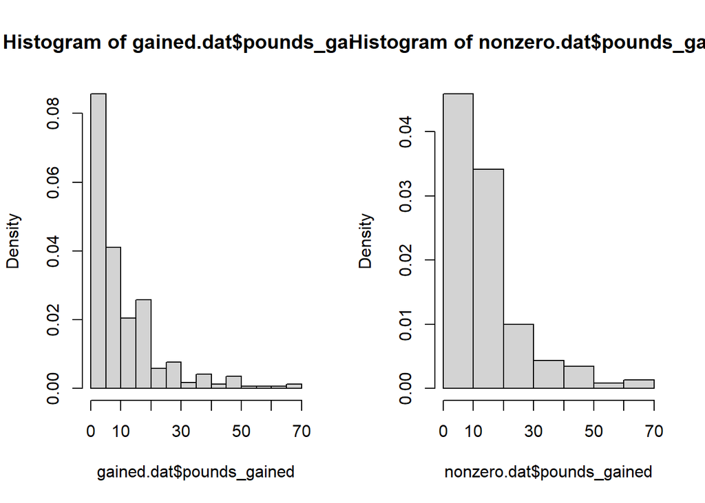

```r
par(mfrow=c(1,2))
hist(gained.dat$pounds_gained, freq = FALSE)
nonzero.dat <- gained.dat[gained.dat$pounds_gained>0,]
hist(nonzero.dat$pounds_gained, freq = FALSE)
```

Pounds gained is highly skewed, even when zero observations are excluded. Thus, a linear model, with the assumption of normally distributed errors, may not be appropriate.

## Linear model, gaussian errors

```r
SA1.model1.lm <- lm(pounds_gained ~ CalcTMM, data=gained.dat)
summary(SA1.model1.lm)
```

```
##
## Call:
## lm(formula = pounds_gained ~ CalcTMM, data = gained.dat)
##
## Residuals:
##     Min      1Q  Median      3Q     Max
## -11.496 -11.348  -3.441   6.672  58.545
##
## Coefficients:
##               Estimate Std. Error t value Pr(>|t|)
## (Intercept) 11.4958780  0.9241793  12.439   <2e-16 ***
## CalcTMM     -0.0000697  0.0004500  -0.155    0.877
## ---
## Signif. codes:  0 '***' 0.001 '**' 0.01 '*' 0.05 '.' 0.1 ' ' 1
##
## Residual standard error: 13.01 on 339 degrees of freedom
## Multiple R-squared:  7.076e-05,  Adjusted R-squared:  -0.002879
## F-statistic: 0.02399 on 1 and 339 DF,  p-value: 0.877
```

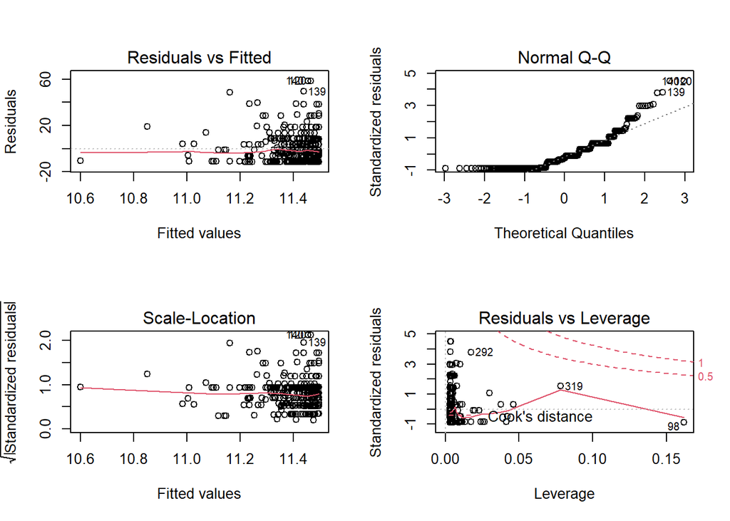

```r
par(mfrow=c(2,2))
plot(SA1.model1.lm)
```

```r
#equivalent model, just using glm instead of lm
SA1.model1.gauss <- glm(pounds_gained ~ CalcTMM, data=gained.dat,family = gaussian)
SA1b.model1.gauss <- glm(pounds_gained ~ CalcTMM, data=nonzero.dat,family = gaussian)
summary(SA1.model1.gauss)
```

```
##
## Call:
## glm(formula = pounds_gained ~ CalcTMM, family = gaussian, data = gained.dat)
##
## Deviance Residuals:
##     Min       1Q   Median       3Q      Max
## -11.496  -11.348   -3.441    6.672   58.545
##
## Coefficients:
##               Estimate Std. Error t value Pr(>|t|)
## (Intercept) 11.4958780  0.9241793  12.439   <2e-16 ***
## CalcTMM     -0.0000697  0.0004500  -0.155    0.877
## ---
## Signif. codes:  0 '***' 0.001 '**' 0.01 '*' 0.05 '.' 0.1 ' ' 1
##
## (Dispersion parameter for gaussian family taken to be 169.2323)
##
##     Null deviance: 57374  on 340  degrees of freedom
## Residual deviance: 57370  on 339  degrees of freedom
## AIC: 2721.5
##
## Number of Fisher Scoring iterations: 2
```

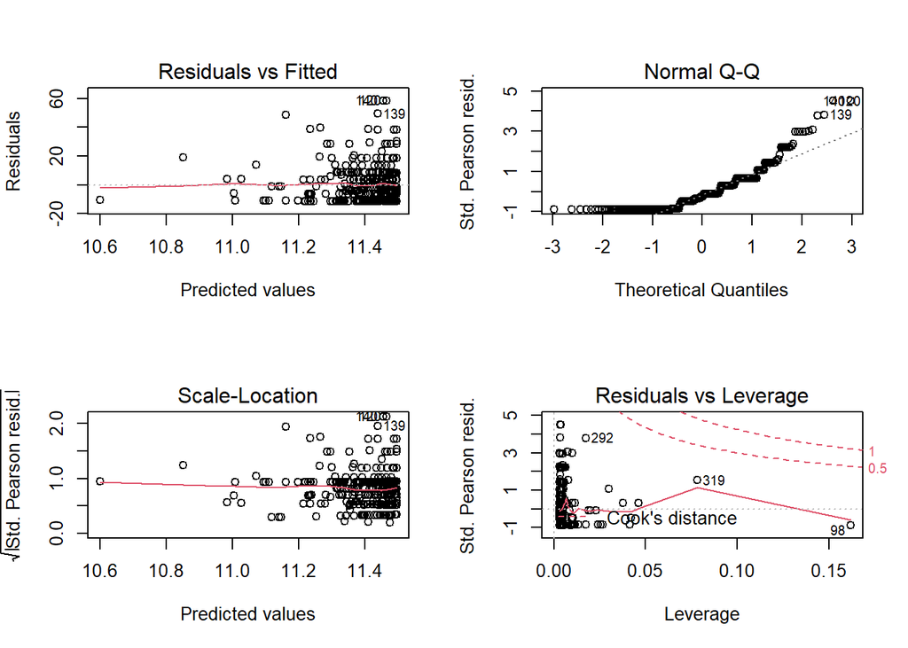

```r
par(mfrow=c(2,2))
plot(SA1.model1.gauss)
```

## Log-normal

```r
#error in log(0)
SA1.model1.log <- lm(log(pounds_gained+0.1) ~ CalcTMM, data=gained.dat)
summary(SA1.model1.log)
```

```
##
## Call:
## lm(formula = log(pounds_gained + 0.1) ~ CalcTMM, data = gained.dat)
##
## Residuals:
##    Min     1Q Median     3Q    Max
## -3.419 -3.259  1.046  1.892  3.343
##
## Coefficients:
##               Estimate Std. Error t value Pr(>|t|)
## (Intercept)  1.116e+00  1.677e-01   6.654 1.15e-10 ***
## CalcTMM     -7.567e-05  8.167e-05  -0.927    0.355
## ---
## Signif. codes:  0 '***' 0.001 '**' 0.01 '*' 0.05 '.' 0.1 ' ' 1
##
## Residual standard error: 2.361 on 339 degrees of freedom
## Multiple R-squared:  0.002526,   Adjusted R-squared:  -0.0004164
## F-statistic: 0.8585 on 1 and 339 DF,  p-value: 0.3548
```

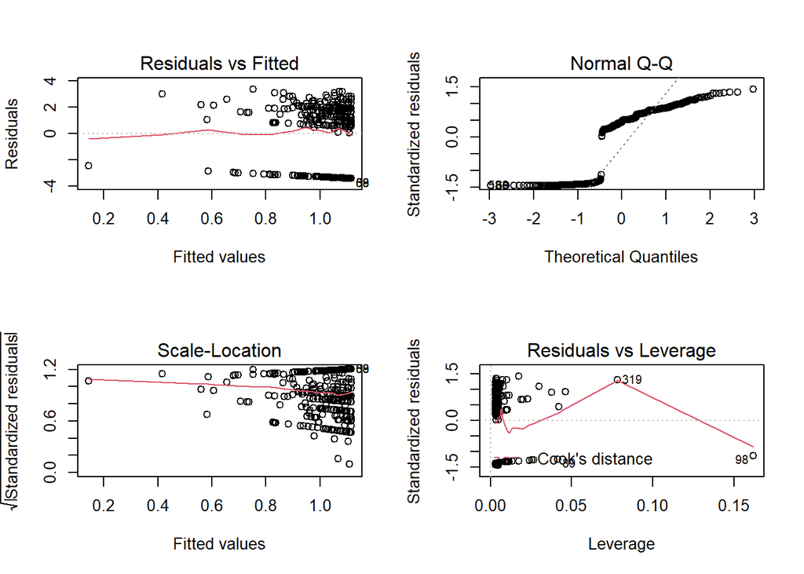

```r
par(mfrow=c(2,2))
plot(SA1.model1.log)
```

An alternative method, may make it easier to compare models.

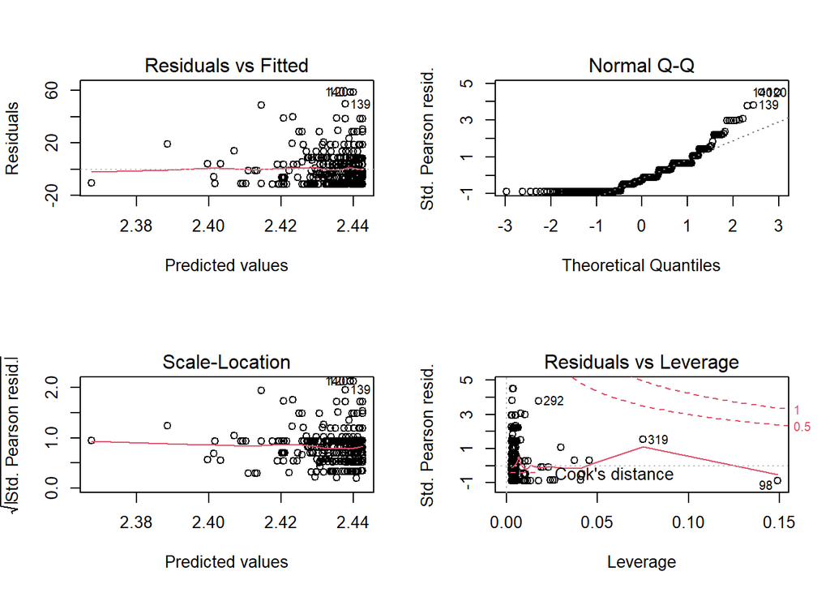

```r
#error in log(0)
SA1.model1.loggauss <- glm(pounds_gained+0.01 ~ CalcTMM, data=gained.dat,family = gaussian(link="log"))
SA1b.model1.loggauss <- glm(pounds_gained ~ CalcTMM, data=nonzero.dat,family = gaussian(link="log"))
par(mfrow=c(2,2))
plot(SA1.model1.loggauss)
```

## Poisson regression

Poisson regression requires integer values. We’ll round pounds gained for this.

```r
gained.dat$LBS <- round(gained.dat$pounds_gained)
nonzero.dat$LBS <- round(nonzero.dat$pounds_gained)
```

```r
SA1.model1.poisson <- glm(LBS ~ CalcTMM, data=gained.dat,family = poisson)
SA1b.model1.poisson <- glm(LBS ~ CalcTMM, data=nonzero.dat,family = poisson)
summary(SA1.model1.poisson)
```

```
##
## Call:
## glm(formula = LBS ~ CalcTMM, family = poisson, data = gained.dat)
##
## Deviance Residuals:
##    Min      1Q  Median      3Q     Max
## -4.796  -4.764  -1.077   1.824  11.675
##
## Coefficients:
##               Estimate Std. Error z value Pr(>|z|)
## (Intercept)  2.442e+00  2.105e-02 116.024   <2e-16 ***
## CalcTMM     -6.262e-06  1.038e-05  -0.604    0.546
## ---
## Signif. codes:  0 '***' 0.001 '**' 0.01 '*' 0.05 '.' 0.1 ' ' 1
##
## (Dispersion parameter for poisson family taken to be 1)
##
##     Null deviance: 4843.1  on 340  degrees of freedom
## Residual deviance: 4842.8  on 339  degrees of freedom
## AIC: 5872.4
##
## Number of Fisher Scoring iterations: 5
```

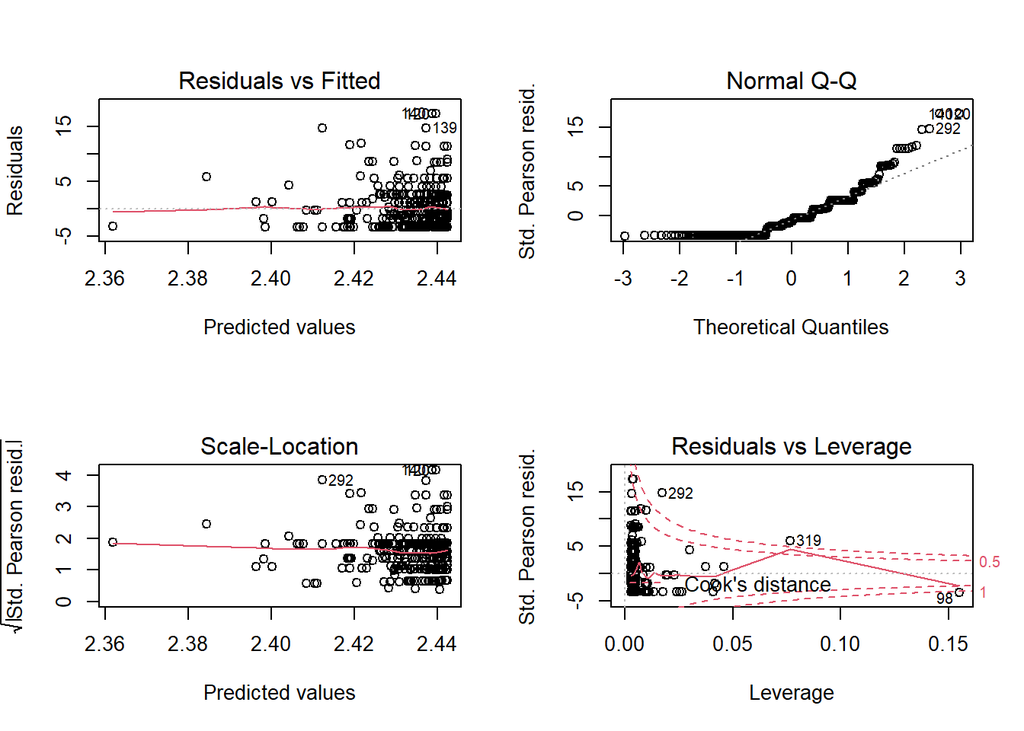

```r
par(mfrow=c(2,2))
plot(SA1.model1.poisson)
```

We can, alternatively, fit a quasi-poisson family. This does not require integer values. This also provides a dispersion parameter that may help account for excess 0s.

```r
SA1.model1.quasi <- glm(pounds_gained ~ CalcTMM, data=gained.dat,family = quasipoisson)
SA1b.model1.quasi <- glm(pounds_gained ~ CalcTMM, data=nonzero.dat,family = quasipoisson)
summary(SA1.model1.quasi)
```

```
##
## Call:
## glm(formula = pounds_gained ~ CalcTMM, family = quasipoisson,
##     data = gained.dat)
##
## Deviance Residuals:
##    Min      1Q  Median      3Q     Max
## -4.795  -4.764  -1.076   1.825  11.675
##
## Coefficients:
##               Estimate Std. Error t value Pr(>|t|)
## (Intercept)  2.442e+00  8.112e-02  30.106   <2e-16 ***
## CalcTMM     -6.192e-06  3.998e-05  -0.155    0.877
## ---
## Signif. codes:  0 '***' 0.001 '**' 0.01 '*' 0.05 '.' 0.1 ' ' 1
##
## (Dispersion parameter for quasipoisson family taken to be 14.84767)
##
##     Null deviance: 4843.5  on 340  degrees of freedom
## Residual deviance: 4843.1  on 339  degrees of freedom
## AIC: NA
##
## Number of Fisher Scoring iterations: 5
```

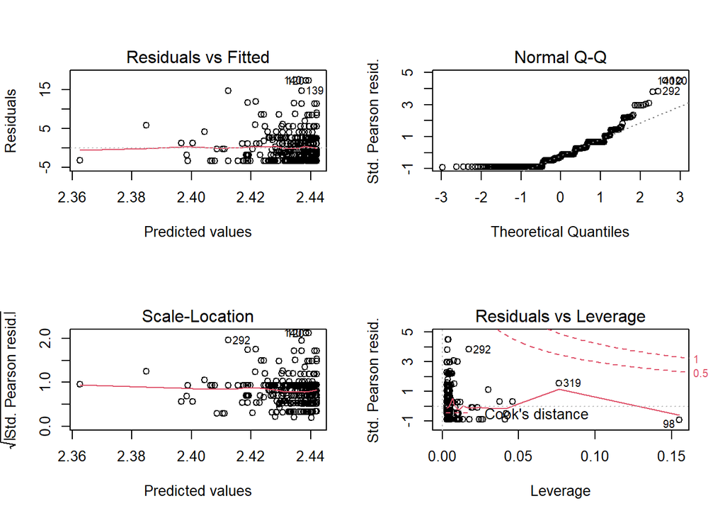

```r
par(mfrow=c(2,2))
plot(SA1.model1.quasi)
```

```r
SA1b.model1.Gamma <- glm(pounds_gained ~ CalcTMM, data=nonzero.dat,family = Gamma)
summary(SA1b.model1.Gamma)
```

```
##
## Call:
## glm(formula = pounds_gained ~ CalcTMM, family = Gamma, data = nonzero.dat)
##
## Deviance Residuals:
##     Min       1Q   Median       3Q      Max
## -1.3342  -0.6515  -0.1289   0.1995   1.8965
##
## Coefficients:
##               Estimate Std. Error t value Pr(>|t|)
## (Intercept)  6.123e-02  3.902e-03  15.690   <2e-16 ***
## CalcTMM     -1.385e-06  1.890e-06  -0.733    0.464
## ---
## Signif. codes:  0 '***' 0.001 '**' 0.01 '*' 0.05 '.' 0.1 ' ' 1
##
## (Dispersion parameter for Gamma family taken to be 0.5586371)
##
##     Null deviance: 109.58  on 230  degrees of freedom
## Residual deviance: 109.30  on 229  degrees of freedom
## AIC: 1701.6
##
## Number of Fisher Scoring iterations: 6
```

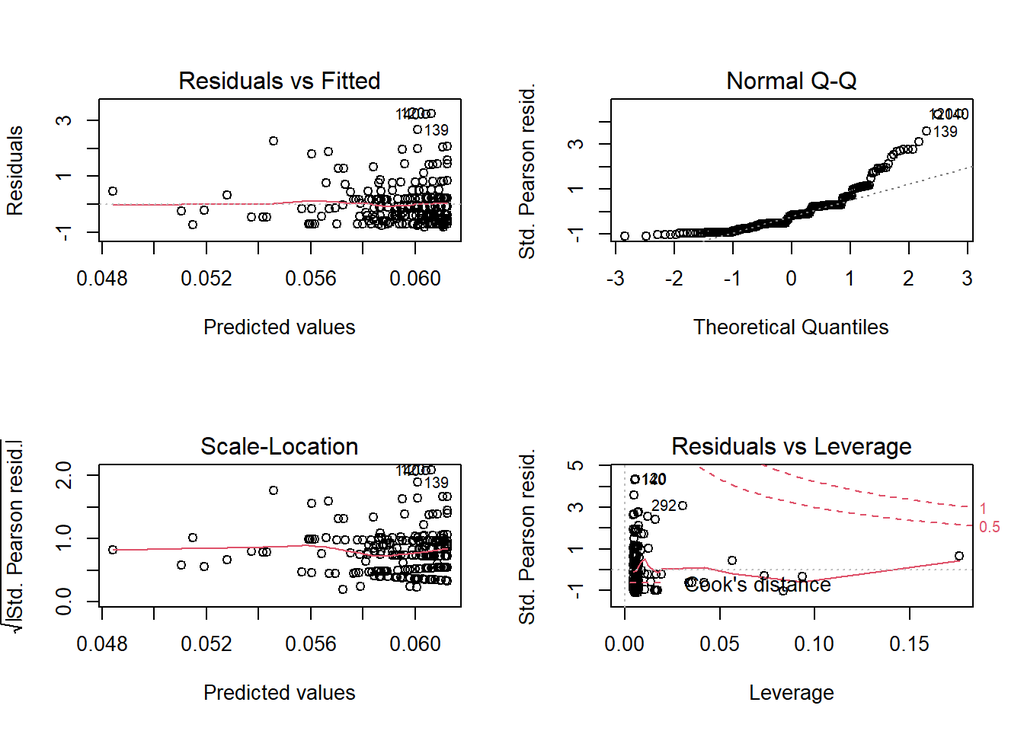

```r
par(mfrow=c(2,2))
plot(SA1b.model1.Gamma)
```

## Model family comparison

```r
anova(SA1.model1.gauss,
      SA1.model1.loggauss,
      SA1.model1.poisson,
      SA1.model1.quasi)
```

```
## Analysis of Deviance Table
##
## Model 1: pounds_gained ~ CalcTMM
## Model 2: pounds_gained ~ CalcTMM
##   Resid. Df Resid. Dev Df Deviance
## 1       339      57370
## 2       339       4843  0    52527
```

```r
anova(SA1b.model1.gauss,
      SA1b.model1.loggauss,
      SA1b.model1.poisson,
      SA1b.model1.quasi,
      SA1b.model1.Gamma)
```

```
## Analysis of Deviance Table
##
## Model 1: pounds_gained ~ CalcTMM
## Model 2: pounds_gained ~ CalcTMM
## Model 3: pounds_gained ~ CalcTMM
## Model 4: pounds_gained ~ CalcTMM
##   Resid. Df Resid. Dev Df Deviance
## 1       229      36174
## 2       229      36172  0        2
## 3       229       1810  0    34362
## 4       229        109  0     1700
```

```r
library(pscl)
summary(zero.model1 <- zeroinfl(LBS ~ CalcTMM, data = gained.dat))
```

```
##
## Call:
## zeroinfl(formula = LBS ~ CalcTMM, data = gained.dat)
##
## Pearson residuals:
##     Min      1Q  Median      3Q     Max
## -1.3941 -1.2980 -0.4077  0.7914  7.0383
##
## Count model coefficients (poisson with log link):
##              Estimate Std. Error z value Pr(>|z|)
## (Intercept) 2.792e+00        NaN     NaN      NaN
## CalcTMM     2.426e-05        NaN     NaN      NaN
##
## Zero-inflation model coefficients (binomial with logit link):
##               Estimate Std. Error z value Pr(>|z|)
## (Intercept) -8.509e-01  1.851e-01  -4.596 4.32e-06 ***
## CalcTMM      8.009e-05  1.241e-04   0.646    0.519
## ---
## Signif. codes:  0 '***' 0.001 '**' 0.01 '*' 0.05 '.' 0.1 ' ' 1
##
## Number of iterations in BFGS optimization: 1
## Log-likelihood: -1631 on 4 Df
```

```r
#par(mfrow=c(1,1))
hist(gained.dat$pounds_gained, freq = FALSE,ylim=c(0,max(dpois(0:70, mean(gained.dat$pounds_gained)))))
100*abs(sd(gained.dat$pounds_gained)-mean(gained.dat$pounds_gained))/mean(gained.dat$pounds_gained)
```

```
## [1] 13.91729
```

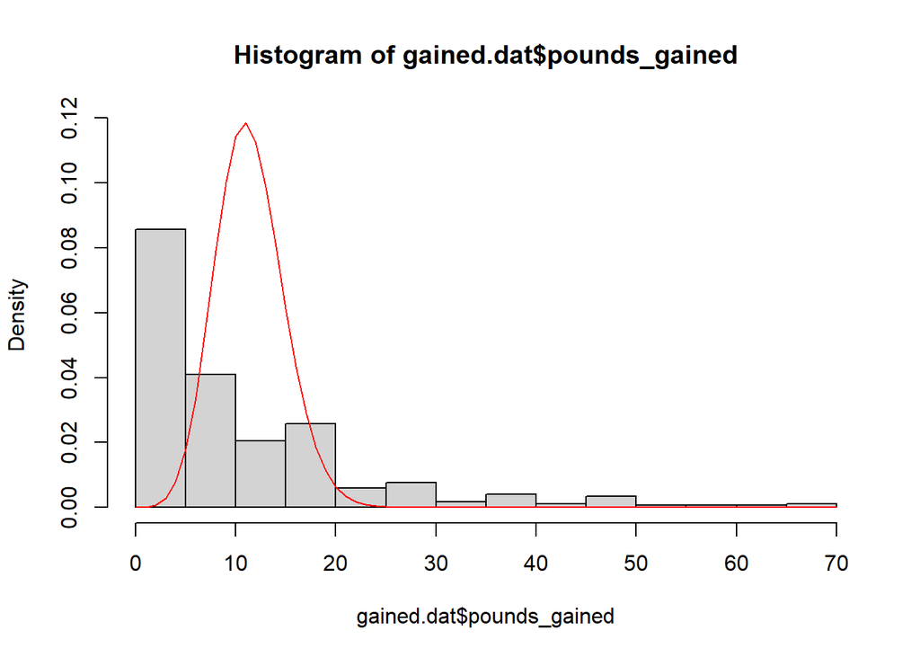

```r
lines(0:70,dpois(0:70,mean(gained.dat$pounds_gained)),col='red')
```

```r
mean(gained.dat$pounds_gained)
```

```
## [1] 11.40323
```

```r
sd(gained.dat$pounds_gained)
```

```
## [1] 12.99025
```

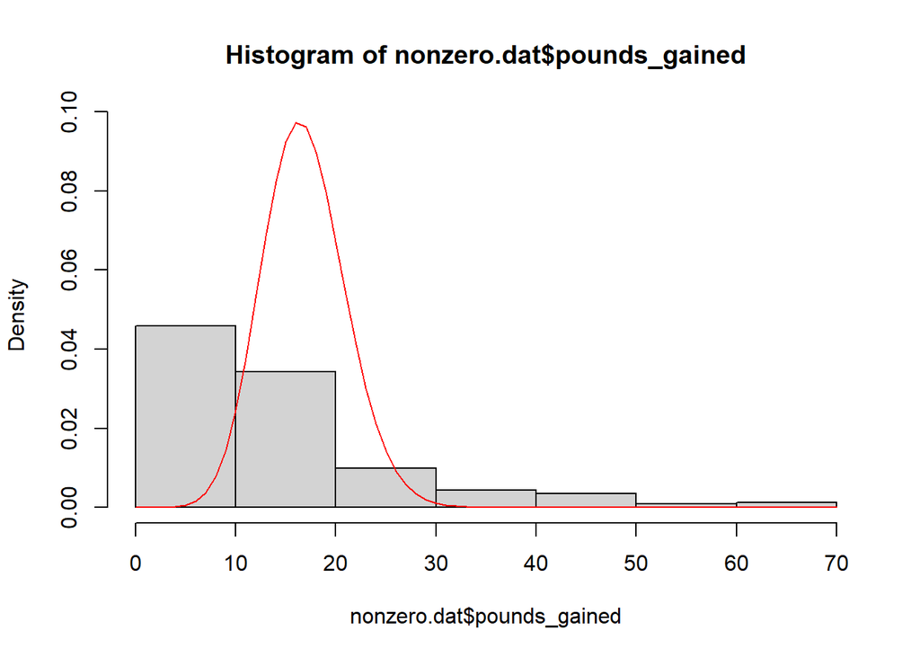

```r
hist(nonzero.dat$pounds_gained, freq = FALSE,ylim=c(0,max(dpois(0:70, mean(nonzero.dat$pounds_gained)))))
lines(0:70,dpois(0:70,mean(nonzero.dat$pounds_gained)),col='red')
```

```r
mean(nonzero.dat$pounds_gained)
```

```
## [1] 16.83333
```

```r
sd(nonzero.dat$pounds_gained)
```

```
## [1] 12.55576
```

```r
100*abs(sd(nonzero.dat$pounds_gained)-mean(nonzero.dat$pounds_gained))/mean(nonzero.dat$pounds_gained)
```

```
## [1] 25.41133
```

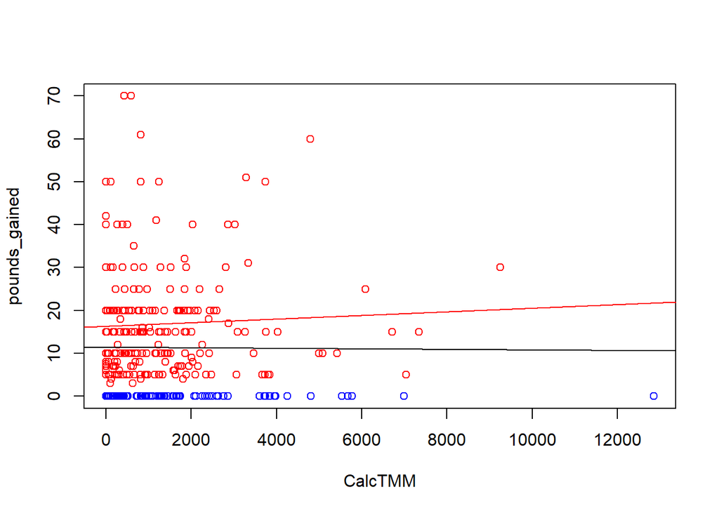

```r
colors <- rep('red',dim(gained.dat)[1])
colors[gained.dat$pounds_gained==0] <- 'blue'
plot(pounds_gained~CalcTMM,gained.dat,col=colors)
abline(lm(pounds_gained~CalcTMM,gained.dat))
abline(lm(pounds_gained~CalcTMM,nonzero.dat),col='red')
```

```r
#missing values for gender
sum(gained.dat$gender=='')
```

```
## [1] 5
```

```r
gained.dat <- gained.dat[!gained.dat$gender=='',]

sum(is.na(gained.dat$Age))
```

```
## [1] 25
```

```r
sum(is.na(gained.dat$height))
```

```
## [1] 17
```

```r
sum(is.na(gained.dat$shift))
```

```
## [1] 0
```

```r
sum(is.na(gained.dat$initial_BMI))
```

```
## [1] 89
```

```r
SA12.model4.quasi <- glm(pounds_gained ~ gender + Age + height + shift + Vig.ex.Time  + Mod.ex.time + Walk.ex.Time, data=gained.dat,family = quasipoisson)
SA12b.model4.quasi <- glm(pounds_gained ~ gender + Age + height + shift + Vig.ex.Time  + Mod.ex.time + Walk.ex.Time, data=nonzero.dat,family = quasipoisson)
summary(SA12.model4.quasi)
```

```
##
## Call:
## glm(formula = pounds_gained ~ gender + Age + height + shift +
##     Vig.ex.Time + Mod.ex.time + Walk.ex.Time, family = quasipoisson,
##     data = gained.dat)
##
## Deviance Residuals:
##     Min       1Q   Median       3Q      Max
## -5.8262  -3.9908  -0.7968   1.5235  10.2409
##
## Coefficients:
##                Estimate Std. Error t value Pr(>|t|)
## (Intercept)   1.997e+00  1.423e+00   1.403   0.1617
## genderMale   -1.361e-01  1.926e-01  -0.707   0.4804
## Age          -4.010e-03  6.488e-03  -0.618   0.5370
## height        1.219e-02  2.106e-02   0.579   0.5630
## shift8am      2.228e-02  2.320e-01   0.096   0.9235
## shift9am     -2.681e-01  2.656e-01  -1.009   0.3136
## shift10am    -2.353e-01  2.731e-01  -0.862   0.3896
## shift11am    -5.791e-01  3.045e-01  -1.902   0.0582 .
## shift12pm    -6.464e-01  4.392e-01  -1.472   0.1421
## shift1pm     -1.140e+00  6.580e-01  -1.733   0.0841 .
## shift2pm      3.968e-01  3.503e-01   1.133   0.2582
## shiftother    7.590e-02  3.435e-01   0.221   0.8253
## shiftmissing  5.668e-01  5.897e-01   0.961   0.3373
## Vig.ex.Time  -7.877e-04  6.256e-04  -1.259   0.2090
## Mod.ex.time  -3.765e-05  4.212e-04  -0.089   0.9288
## Walk.ex.Time  1.799e-04  2.860e-04   0.629   0.5300
## ---
## Signif. codes:  0 '***' 0.001 '**' 0.01 '*' 0.05 '.' 0.1 ' ' 1
##
## (Dispersion parameter for quasipoisson family taken to be 13.56852)
##
##     Null deviance: 4266.8  on 304  degrees of freedom
## Residual deviance: 3966.5  on 289  degrees of freedom
##   (31 observations deleted due to missingness)
## AIC: NA
##
## Number of Fisher Scoring iterations: 5
```

```r
summary(SA12b.model4.quasi)
```

```
##
## Call:
## glm(formula = pounds_gained ~ gender + Age + height + shift +
##     Vig.ex.Time + Mod.ex.time + Walk.ex.Time, family = quasipoisson,
##     data = nonzero.dat)
##
## Deviance Residuals:
##     Min       1Q   Median       3Q      Max
## -4.5213  -2.2259  -0.5795   0.9458   8.7157
##
## Coefficients:
##                Estimate Std. Error t value Pr(>|t|)
## (Intercept)   1.365e+00  1.784e+00   0.765   0.4450
## genderFemale  1.167e+00  1.337e+00   0.873   0.3838
## genderMale    1.257e+00  1.345e+00   0.934   0.3513
## Age          -2.322e-03  4.957e-03  -0.468   0.6400
## height        7.164e-03  1.775e-02   0.404   0.6869
## shift8am      3.490e-02  1.852e-01   0.188   0.8508
## shift9am     -1.810e-01  2.167e-01  -0.835   0.4046
## shift10am    -3.269e-01  2.158e-01  -1.515   0.1314
## shift11am    -5.329e-01  2.405e-01  -2.215   0.0279 *
## shift12pm    -5.345e-01  3.484e-01  -1.534   0.1266
## shift1pm     -1.015e+00  5.190e-01  -1.956   0.0519 .
## shift2pm      1.534e-01  2.803e-01   0.547   0.5848
## shiftother   -1.222e-02  2.731e-01  -0.045   0.9644
## shiftmissing  1.540e-01  4.661e-01   0.330   0.7414
## Vig.ex.Time  -2.909e-04  5.325e-04  -0.546   0.5855
## Mod.ex.time  -3.893e-05  3.479e-04  -0.112   0.9110
## Walk.ex.Time  2.865e-04  2.303e-04   1.244   0.2149
## ---
## Signif. codes:  0 '***' 0.001 '**' 0.01 '*' 0.05 '.' 0.1 ' ' 1
##
## (Dispersion parameter for quasipoisson family taken to be 8.460038)
##
##     Null deviance: 1644.3  on 211  degrees of freedom
## Residual deviance: 1419.4  on 195  degrees of freedom
##   (19 observations deleted due to missingness)
## AIC: NA
##
## Number of Fisher Scoring iterations: 5
```

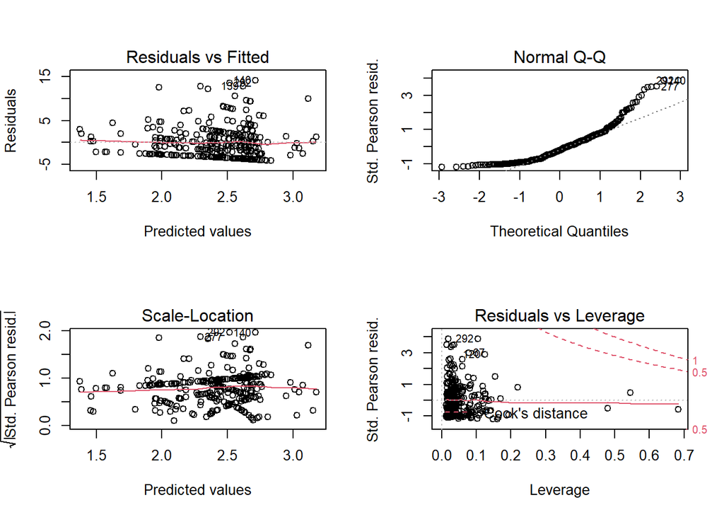

```r
par(mfrow=c(2,2))
plot(SA12.model4.quasi)
```

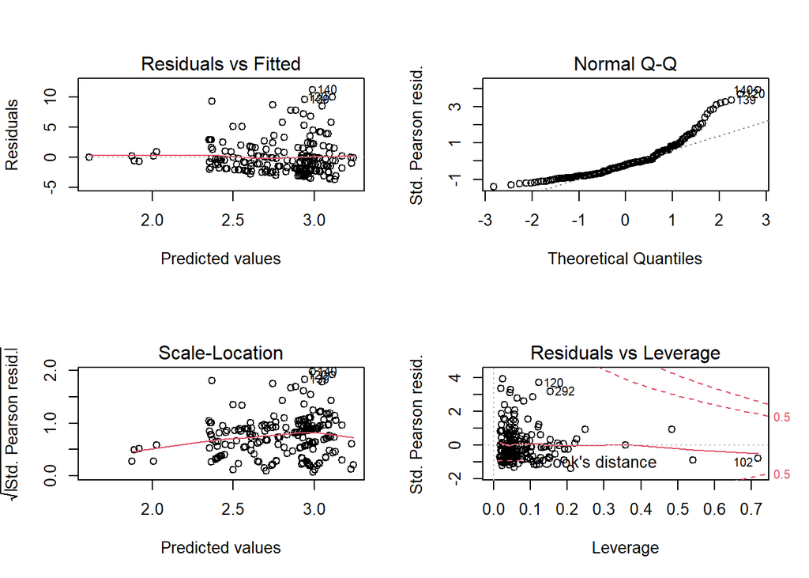

```r
par(mfrow=c(2,2))
plot(SA12b.model4.quasi)
```

```r
zero.model4 <- zeroinfl(LBS ~ gender + Age + height + shift + Vig.ex.Time + Mod.ex.time + Walk.ex.Time + initial_BMI, data = gained.dat)
summary(zero.model4)
```

```
##
## Call:
## zeroinfl(formula = LBS ~ gender + Age + height + shift + Vig.ex.Time +
##     Mod.ex.time + Walk.ex.Time + initial_BMI, data = gained.dat)
##
## Pearson residuals:
##     Min      1Q  Median      3Q     Max
## -3.1316 -1.1042 -0.3269  0.6359  8.7833
##
## Count model coefficients (poisson with log link):
##                Estimate Std. Error z value Pr(>|z|)
## (Intercept)   2.310e+00  4.613e-01   5.007 5.53e-07 ***
## genderMale    1.250e-01  5.941e-02   2.103 0.035433 *
## Age          -6.671e-03  1.996e-03  -3.342 0.000833 ***
## height        5.499e-03  6.793e-03   0.810 0.418180
## shift8am      7.081e-02  7.100e-02   0.997 0.318546
## shift9am     -7.748e-02  8.296e-02  -0.934 0.350334
## shift10am    -3.156e-01  8.144e-02  -3.876 0.000106 ***
## shift11am    -6.429e-01  9.783e-02  -6.572 4.97e-11 ***
## shift12pm    -5.664e-01  1.238e-01  -4.577 4.73e-06 ***
## shift1pm     -9.416e-01  1.939e-01  -4.857 1.19e-06 ***
## shift2pm      2.807e-01  1.135e-01   2.474 0.013373 *
## shiftother    1.088e-01  1.001e-01   1.086 0.277324
## shiftmissing  5.939e-02  1.637e-01   0.363 0.716857
## Vig.ex.Time  -3.060e-04  1.940e-04  -1.578 0.114679
## Mod.ex.time  -7.765e-05  1.100e-04  -0.706 0.480137
## Walk.ex.Time  2.890e-04  7.583e-05   3.812 0.000138 ***
## initial_BMI   1.769e-02  3.648e-03   4.849 1.24e-06 ***
##
## Zero-inflation model coefficients (binomial with logit link):
##                Estimate Std. Error z value Pr(>|z|)
## (Intercept)  -7.770e-01  3.433e+00  -0.226   0.8209
## genderMale    6.207e-01  4.201e-01   1.478   0.1395
## Age          -1.485e-02  1.558e-02  -0.953   0.3406
## height       -1.887e-02  4.969e-02  -0.380   0.7041
## shift8am      2.712e-01  5.439e-01   0.499   0.6180
## shift9am     -1.910e-01  6.342e-01  -0.301   0.7632
## shift10am    -6.465e-01  6.564e-01  -0.985   0.3246
## shift11am     2.726e-01  6.273e-01   0.435   0.6638
## shift12pm    -3.460e-01  8.457e-01  -0.409   0.6825
## shift1pm     -7.094e-02  1.023e+00  -0.069   0.9447
## shift2pm     -1.576e+01  1.582e+03  -0.010   0.9921
## shiftother   -1.496e-01  8.437e-01  -0.177   0.8593
## shiftmissing -1.618e+01  2.767e+03  -0.006   0.9953
## Vig.ex.Time   8.323e-04  1.457e-03   0.571   0.5678
## Mod.ex.time   3.164e-04  1.502e-03   0.211   0.8332
## Walk.ex.Time  3.375e-04  6.878e-04   0.491   0.6236
## initial_BMI   5.452e-02  2.689e-02   2.027   0.0427 *
## ---
## Signif. codes:  0 '***' 0.001 '**' 0.01 '*' 0.05 '.' 0.1 ' ' 1
##
## Number of iterations in BFGS optimization: 1
## Log-likelihood: -1069 on 34 Df
```

```r
boots.zero.model1.tbl$Estimate <- coef(zero.model1)
boots.zero.model1.tbl

confint(zero.model1)
```

[output not shown]